# Example data set

2022-10-31

In this script, the data used in the book chapter will be created: predictors based on worldclim, a virtual habitat suitability for a virtual species as response, two different sets of simulated training data, and randomly sampled validation data points.

# Getting started

```r
library(terra)
library(raster)
library(sf)
library(virtualspecies)
```

# Simulation of the training set

Let’s first define settings for the prediction task, like the number of training points, their distribution (in terms of clusters) as well as parameters on how to simulate the response.

## Get data

To prepare the predictors, the bio-climate data are downloaded and cropped to the defined study area.

```r
# download, select and crop predictors:
predictors <- rast("data/worldclim.tif")
```

## Generate Predictors and Response

The virtual response variable is created based on the PCA of a subset of the bioclim predictors. See the virtualspecies package for further information.

```r
#### Simulated predictors and response:
predictornames <- c("bio1","bio2","bio5","bio6","bio7","bio10","bio11","bio12","bio13","bio14","bio15","bio18","bio19")
simulateResponse <- c("bio2","bio5","bio10", "bio13", "bio14","bio19") # variables used to simulate the response
meansPCA <- c(3, -1) # means of the gaussian response functions to the 2 axes
sdPCA <- c(2, 2) # sd's of the gaussian response functions to the 2 axes
seed <- 10
```

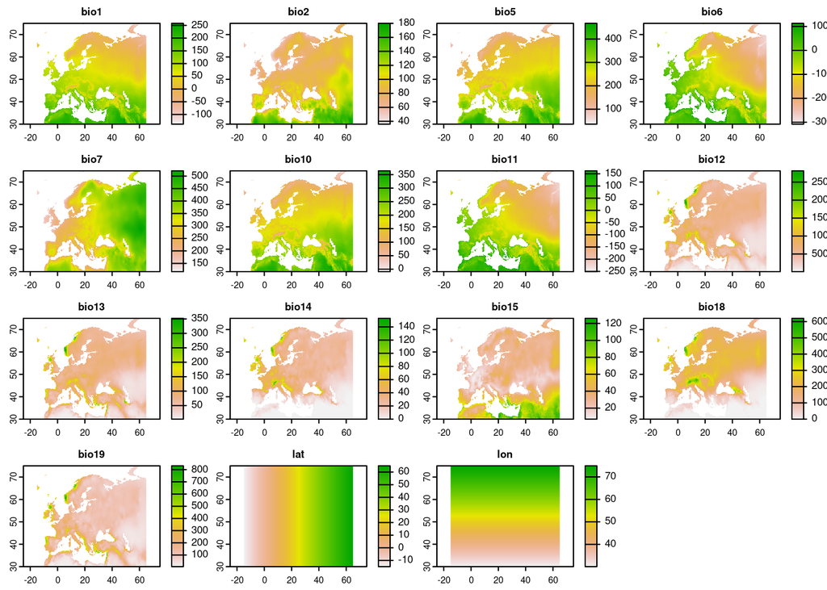

```r
predictors <- predictors[[predictornames]]
coords <- crds(predictors,df=TRUE,na.rm=FALSE)
predictors$lat <- predictors[[1]]
values(predictors$lat) <- coords[,1]
predictors$lon <- predictors[[1]]
values(predictors$lon) <- coords[,2]

plot(predictors)
```

```r
writeRaster(predictors,"data/predictors.tif",overwrite=TRUE)
```

```r
response_vs <- generateSpFromPCA(as(predictors[[simulateResponse]],"Raster"),
                                 means = meansPCA,sds = sdPCA, plot=F)
response <- response_vs$suitab.raster
writeRaster(response,"data/response.tif",overwrite=TRUE)
```

## Simulate training and testing points

When looking at typical global prediction studies, we can see that reference data that are used for model training are often extremely clustered in geographic space (see https://www.nature.com/articles/s41467-022-29838-9). To simulate field locations that are typically used as training data, “nclusters” locations are randomly selected (center of clusters). The “npoints” are then distributed over the clusters, with a maximum distance of “maxdist” meters around the center of each cluster. For comparison, randomly distributed training data are created as well.

```r
npoints <- 300 # number of training samples
nclusters <- 10 #number of clusters if design==clustered
maxdist <- 150000 #in unit m. size of the clusters
seed <- 2345
```

```r
#create a mask for land area:
mask <- as(predictors[[1]],"Raster")
values(mask)[!is.na(values(mask))] <- 1
mask <- st_as_sf(rasterToPolygons(mask,dissolve=TRUE))
```

```r
pts_clustered <- clustered_sample(mask,npoints,nclusters,radius=maxdist,seed=seed)
set.seed(seed)
pts_random <- st_sample(mask, npoints)
```

```r
set.seed(1)
validationpoints <- st_sample(mask, npoints)
```

Now let’s visualize the created response variable and the training data points

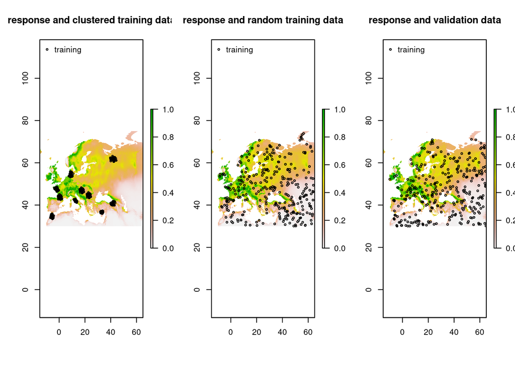